# Preferencias laborales de los alumnos de pregrado de la Universidad de Ingeniería y Tecnología con relación a Ciencia de la Computación

### Rubro mas popular

Es importante para la universidad conocer cual es el rubro de mayor interés para sus alumnos para así organizar workshops o aumentar el énfasis en el área. Se sabe que el rubro de interés mas popular es Inteligencia Artificial, pero ¿cual es la probabilidad de que encuentre a un estudiante con este interés la quinta vez que se le pregunta a alguien?

Se define una variable aleatoria $\mathbb{X}$ que cuenta el número de experimentos Ber($p$), independientes y con $p$ fija, necesarios para lograr el primer éxito.

Variable Aleatoria: $\mathbb{X}$: Número de estudiantes no interesados en Inteligencia Artificial como rubro antes de encontrar el que si.

```r
round(dgeom(x = 4, prob = 0.27), 2)
```

```
## [1] 0.08
```

La probabilidad de encontrar el estudiante con el interés en el quinto intento es 0.08.

Usamos el siguiente gráfico para visualizar las probabilidades en un número de intentos.

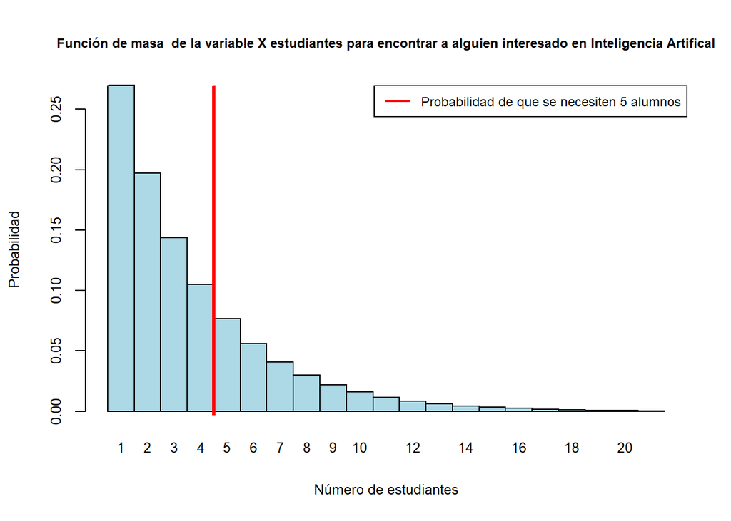

```r
barplot(dgeom(x = 0:20, prob = 0.27), names.arg = c(1:21), main = "Función de masa  de la variable X estudiantes para encontrar a alguien interesado en Inteligencia Artifical", ylab = "Probabilidad", xlab = "Número de estudiantes", col = coloresbarra,
     cex.axis=0.8, cex.names=0.8, cex.lab=0.8, cex.main=0.76, space = FALSE)
abline(v = 4, lwd = 3, col = "red")
legend('topright',legend="Probabilidad de que se necesiten 5 alumnos",col="red",lwd=2,cex=0.75)
```

### Perú como país de desarollo para rubro

Los convenios de la universidad son importantes para proveer a estudiantes una experiencia internacional. Estos son populares especialmente si es que el estudiante desea trabajar en su país de destino. Aún así, muchos alumnos prefieren quedarse en Perú para desarrollar su rubro. ¿Cuál es la probabilidad de que finalmente se encuentre con un alumno que desee quedarse en el país preguntado a un total de 7 alumnos?

Se define una variable aleatoria $\mathbb{X}$ que cuenta el número de experimentos Ber($p$), independientes y con $p$ fija, necesarios para lograr el primer éxito.

Variable Aleatoria: $\mathbb{X}$: Número de estudiantes no interesados quedarse a trabajar en Perú antes de encontrar el que si.

```r
round(dgeom(x = 6, prob = 0.15), 2)
```

```
## [1] 0.06
```

La probabilidad de encontrar el estudiante que quiere quedarse en el séptimo intento es 0.06.

Usamos el siguiente gráfico para visualizar las probabilidades en un número de intentos.

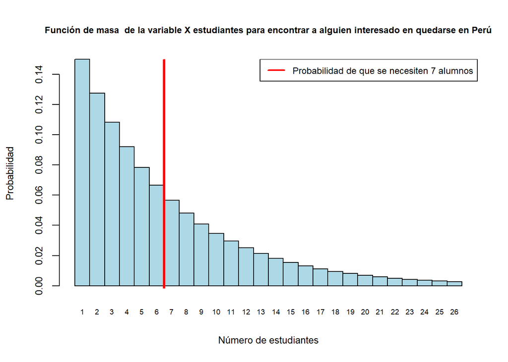

```r
barplot(dgeom(x = 0:25, prob = 0.15), names.arg = c(1:26), main = "Función de masa  de la variable X estudiantes para encontrar a alguien interesado en quedarse en Perú", ylab = "Probabilidad", xlab = "Número de estudiantes", col = coloresbarra,
     cex.axis=0.8, cex.names=0.6, cex.lab=0.8, cex.main=0.76, space = FALSE)
abline(v = 6, lwd = 3, col = "red")
legend('topright',legend="Probabilidad de que se necesiten 7 alumnos",col="red",lwd=2,cex=0.75)
```

Como se puede observar, la probabilidad de encontrar al estudiante decrece mientras mas preguntas, lo que indica que es algo rápido de averiguar.

### Desarrollo en el extranjero

Sea la variable aleatoria $\mathbb{X}$ que cuenta el número de alumnos que quieren irse a trabajar al extranjero que se obtienen al extraer $k$ alumnos de un auditorio con $N$ alumnos de los cuales $n$ son alumnos que quieren irse al extranjero para trabajar.

Variable Aleatoria: $\mathbb{X}$: Número de estudiantes no interesados en quedarse a trabajar en Perú.

Se encuentra el número de estudiantes que prefieren estudiar en el extranjero. Tomar en cuenta que aquellos N.A. no son contados.

```r
table(!DF$Pais == "Perú")
```

```
##
## FALSE  TRUE
##    20   110
```

```r
round(phyper(5, 110, 22, 10, lower.tail = FALSE), 2)
```

```
## [1] 0.99
```

La probabilidad de que la mayoría de los alumnos desean trabajar en el extranjero es de 99%, muy alta. Si se les preguntara a todos los alumnos, seria prácticamente unánime que la mayoría prefiere trabajar en el extranjero.

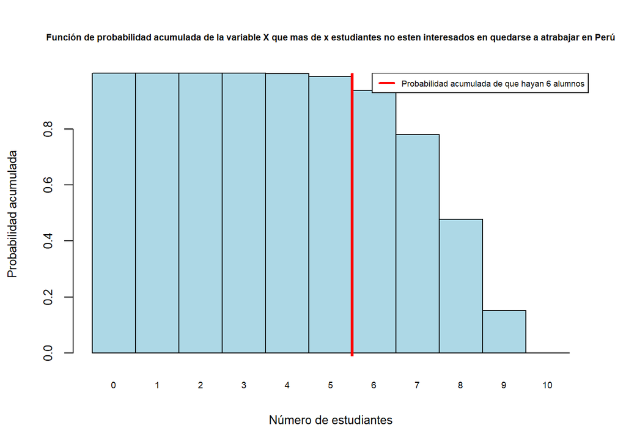

```r
barplot(phyper(0:10, 110, 22, 10, lower.tail = FALSE), names.arg = c(0:10), main = "Función de probabilidad acumulada de la variable X que mas de x estudiantes no esten interesados en quedarse a atrabajar en Perú", ylab = "Probabilidad acumulada", xlab = "Número de estudiantes", col = coloresbarra,
     cex.axis=0.8, cex.names=0.6, cex.lab=0.8, cex.main=0.6, space = FALSE)
abline(v = 6, lwd = 3, col = "red")
legend('topright',legend="Probabilidad acumulada de que hayan 6 alumnos",col="red",lwd=2,cex=0.55)
```

### Preparación, Capacitación y Rechazo

Evento: Los alumnos tienen un valor de preparación, capacitación y rechazo basado en las variables del dataframe **Preparación**, **Capacitación** y **Rechazo**.

#### Preparación

Se tiene interés por saber si el nivel de preparación de los alumnos es alto. En la variable se considera un nivel alto de preparación significativo si es mayor a 5. Entonces, ¿cuál es la probabilidad de que el nivel de preparación de los alumnos sea mayor a 5?

Variable Aleatoria: $\mathbb{X}$: el valor de preparación que tiene un alumno.

$\mathbb{X}$ sigue una distribución normal con parámetros $\mu$ (su media) y $\delta$ (su desviación estándar).

Usamos el modelo normal: $\mathbb{X} \sim N(7.94, 1.47)$ y determinamos $P(\mathbb{X} > 5)$

```r
PrepMedia <- mean(DF$Preparacion)
PrepDS <- sd(DF$Preparacion)
round(pnorm(5, mean = PrepMedia, sd = PrepDS, lower.tail = FALSE), 2)
```

```
## [1] 0.98
```

El resultado es reconfortante. La gran mayoría de los alumnos se sienten seguros de su preparación en la carrera. Es algo que brinda confianza y seguridad para la universidad y con lo que se pueden obtener muy buenos resultados.

Para ver la distribución de la probabilidad se encuentra el siguiente gráfico.

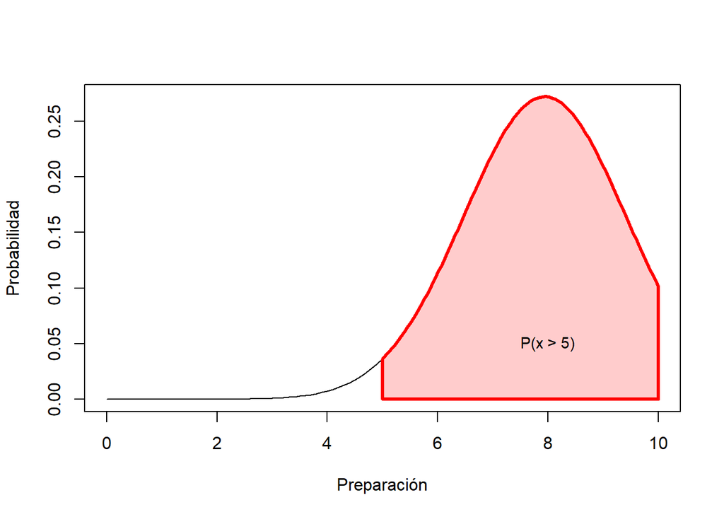

```r
x2 <- c(5, seq(5,10,length=100),10)
y2 <- c(0, dnorm(seq(5,10,length=100), mean = PrepMedia, sd = PrepDS), 0)
curve(dnorm(x, mean = PrepMedia, sd = PrepDS), from=0, to=10, ylab = "Probabilidad", xlab = "Preparación")
polygon(x2, y2, col = "#FFCCCC", border = "red", lwd = 3)
text(x = 8, y = 0.05, 'P(x > 5)' ,cex = 0.9)
```

#### Capacitación

Se necesita conocer la opinión de aquellos alumnos que no se sienten ni muy capacitados ni poco capacitados. No es una situación alarmante tener una opinión neutra pero la cantidad de estudiantes que entren en este rango puede mostrar si es que se tendría que repensar los métodos de enseñanza. Entonces, ¿cuál es la probabilidad de que los estudiantes tengan un valor entre 4 y 6 de capacitación? Una opinión sobre su capacitación neutra.

Variable Aleatoria: $\mathbb{X}$: el valor de capacitación que tiene un alumno.

$\mathbb{X}$ sigue una distribución normal con parámetros $\mu$ (su media) y $\delta$ (su desviación estándar).

```r
CapMedia <- mean(DF$Capacitacion)
CapDS <- sd(DF$Capacitacion)
round(pnorm(6, mean = CapMedia, sd = CapDS) - pnorm(4, mean = CapMedia, sd = CapDS), 2)
```

```
## [1] 0.31
```

La probabilidad de que un estudiante este en este rango es significante pero no es una cifra tan grande como para ser preocupante para la universidad.

Para ver la distribución de la probabilidad se encuentra el siguiente gráfico.

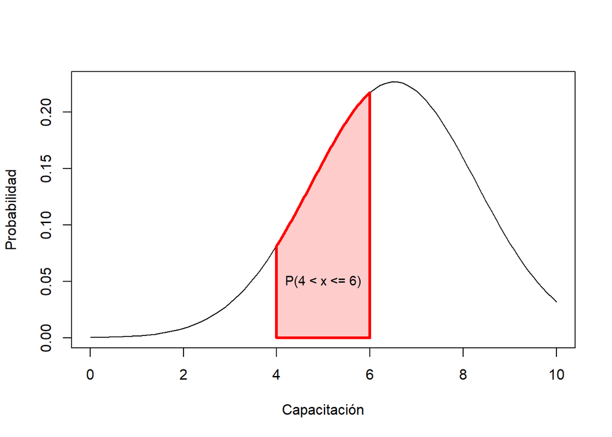

```r
x2 <- c(4, seq(4,6,length=100), 6)
y2 <- c(0, dnorm(seq(4,6,length=100), mean = CapMedia, sd = CapDS), 0)
curve(dnorm(x, mean = CapMedia, sd = CapDS), from=0, to=10, ylab = "Probabilidad", xlab = "Capacitación")
polygon(x2, y2, col = "#FFCCCC", border = "red", lwd = 3)
text(x = 5, y = 0.05, 'P(4 < x <= 6)' ,cex = 0.9)
```

La universidad quiere saber si los estudiantes mantienen una relación saludable con la carrera. En la variable rechazo, un número menor a 5 significa que el rechazo por la carrera no esta latente. Entonces, ¿cuál es la probabilidad de que el nivel de rechazo sea como máximo 5?

Variable Aleatoria: $\mathbb{X}$: el valor de rechazo que tiene un alumno.

$\mathbb{X}$ sigue una distribución normal con parámetros $\mu$ (su media) y $\delta$ (su desviación estándar).

Usamos el modelo normal: $\mathbb{X} \sim N(5.59, 1.78)$ y determinamos $P(\mathbb{X} <= 5)$

```r
RechMedia <- mean(DF$Rechazo)
RechDS <- sd(DF$Rechazo)
round(pnorm(5, mean = RechMedia, sd = RechDS), 2)
```

```
## [1] 0.37
```

Es medio preocupante de que la probabilidad de estudiantes sin rechazo sea un poco baja. Implica que los estudiantes no tienen una relación muy saludable con la carrera.

Para ver la distribución de la probabilidad se encuentra el siguiente gráfico.

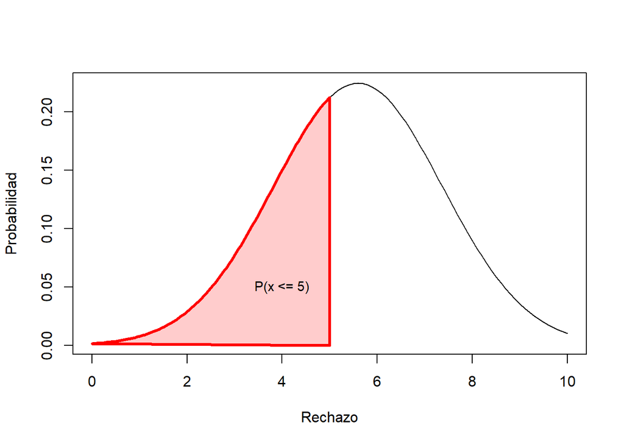

```r
x2 <- c(seq(0,5,length=100),5)
y2 <- c(dnorm(seq(0,5,length=100), mean = RechMedia, sd = RechDS),0)
curve(dnorm(x, mean = RechMedia, sd = RechDS), from=0, to=10, ylab = "Probabilidad", xlab = "Rechazo")
polygon(x2, y2, col = "#FFCCCC", border = "red", lwd = 3)
text(x = 4, y = 0.05, 'P(x <= 5)' ,cex = 0.9)
```

## Hallazgo más importante

Siguiendo el objetivo principal de este estudio, es decir, ver hacía que rubros y regiones apuntan los estudiantes como profesionales de Ciencia de la Computación, se ha hallado que el área de mayor interés entre los alumnos es **Inteligencia Artificial**, con un deseo latente por desarrollarla en los **Estados Unidos de América**. Entendemos que este hallazgo es sumamente relevante ya que dicho rubro está íntimamente relacionado con el desarrollo sostenible (Casal, 2021), y vemos que a los alumnos les interesa combatir el impacto medioambiental, por lo que debe ser aprovechado. Con ello se recomendaría implementar charlas, talleres y cursos donde los alumnos puedan profundizar sus intereses en este rubro que promete mucho y apunta hacia la sostenibilidad. Adicionalmente, sería ideal realizar ello con entidades y profesionales estadounidenses, por el gran deseo de desarrollarse en el respectivo país.

También, solo por la sorpresa que significó, parece conveniente mencionar que se halló que quienes no consideran a Perú como un país viable para su rubro de interés, no son en mayoría quienes logran desenvolverse en el idioma inglés. Uno esperaría que la confianza de desenvolverse en un país foráneo proviene del conocimiento de la lengua más distribuida a lo largo del planeta, pero sorprendentemente ese no es el caso.

## Cierre y Conclusiones

Básicamente, a través de este estudio e investigación se logra entender, comprender y visualizar la realidad y percepción de los alumnos de la Universidad de Ingeniería y Tecnología acerca de la carrera profesional Ciencia de la Computación. A través de todo el proceso, se han tratado aspectos simples como población y muestreo, hasta prácticas más complicadas como análisis descriptivo y de probabilidades. Básicamente, se ha intentado presentar cada una de las variables relevantes de forma amigable, sencilla y práctica, para luego entender más de su comportamiento con el hallazgo de probabilidades, el planteamiento de variables aleatorias y el uso de las respectivas distribuciones. De ello vemos como factores temporales, espaciales y, sobre todo personales influyen fuertemente en la toma de decisiones, el desempeño e incluso en la percepción y confianza que uno tiene sobre su futuro y desarrollo profesional.

En sí, vemos que Ciencia de la Computación es una carrera compleja, que apunta hacia muchos lados y, evidentemente, compleja para decidir la dirección ideal. Cada estudiante la percibe de forma particular y subjetiva, y ello normalmente no es notado por las entidades responsables. Este proyecto da especial atención a esto, por lo que consideramos que permite mejorar el entendimiento y visión sobre dicha carrera. Finalmente, como se mencionó en un inicio, proporciona buena y confiable información para una buena gestión y toma de decisiones, permitiendo saber a qué panorama mirar y qué futuro esperar.

## Bibliografía

Castillo, B. (2021, 28 de abril). Estas son las horas que deberías dedicar al estudio según el tipo de estudiante que eres. DIRECTORIO UNIVERSITARIO. https://guiauniversitaria.mx/estas-son-las-horas-que-deberias-dedicar-al-estudio-segun-el-tipo-de-estudiante-que-eres/

Casal, J. (2021, 10 de mayo). Inteligencia Artificial y Desarrollo Sostenible. Kabel. https://www.kabel.es/inteligencia-artificial-y-desarrollo-sostenible/